# WaterTreatmentKMeans

Justin Murray

10/20/2019

## K-Means

K-means also is known as flat clustering. It does not create a hierarchy of clusters like hierarchical clustering, it requires the number of clusters as an input. K-means does perform faster than hierarchical clustering. K-means clustering uses partitioning clustering with the goal is to partition the number of objects into the number of given clusters with the nearest mean by minimizing the within-cluster sum of squares. The process of k-means can be broken into 5 steps 1. Specify the number of clusters, k 2. Randomly create k partitions 3. Calculate the center of the partitions 4. Associate objects closest to the cluster center 5. Repeat steps 2,3,4 until the WCSS changes very little K-means requires the user to input a number of clusters too.

Let’s run K-Means on the provided water treatment dataset.

Inspect the center of each cluster and draw a scatter plot of the data and color the points according to clusters:

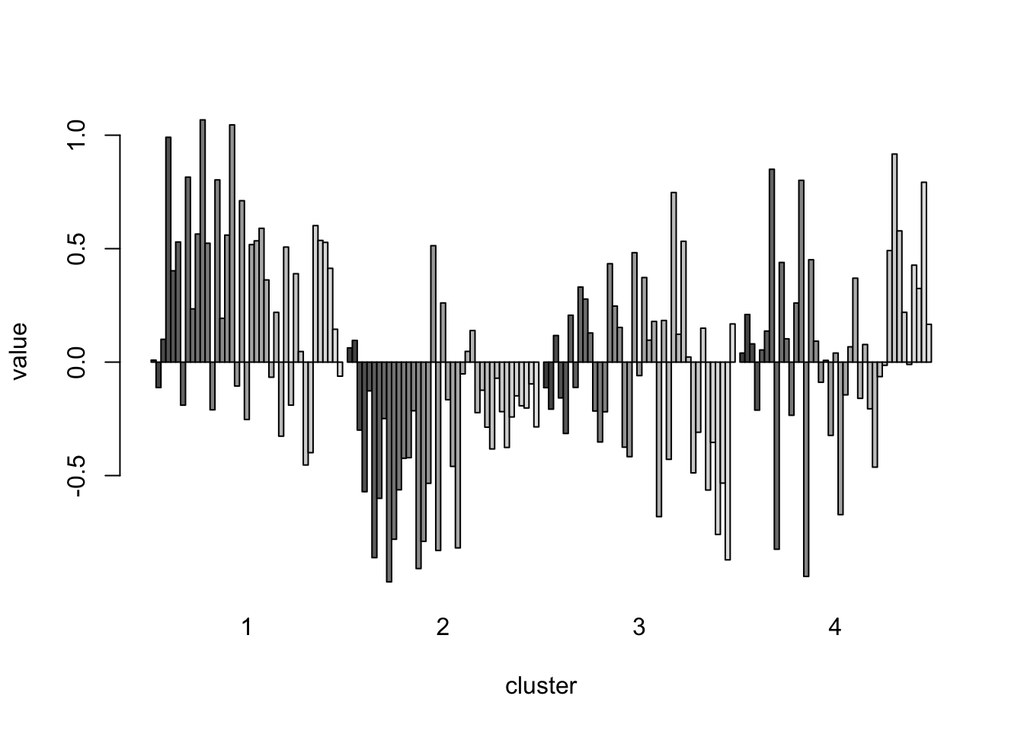

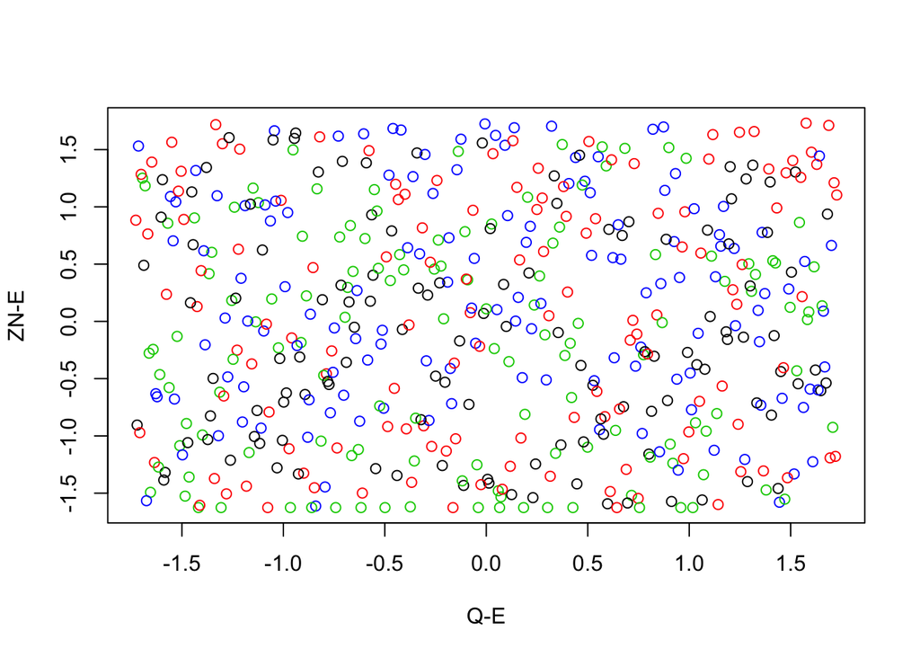

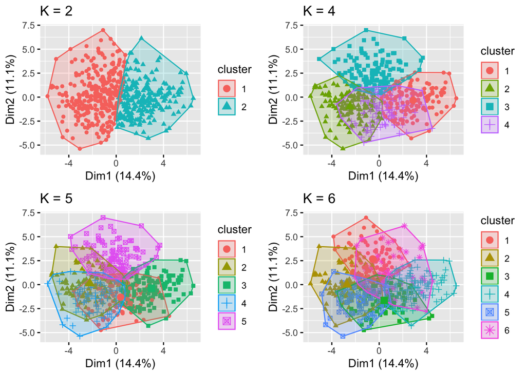

obtaining the optimum number of clusters

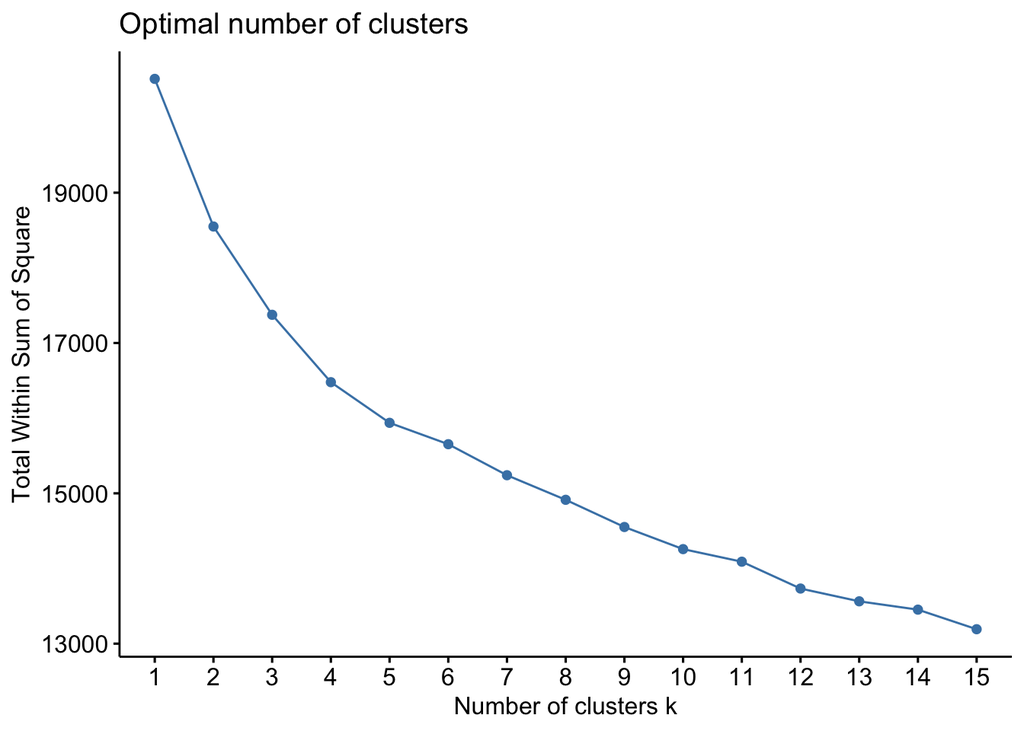

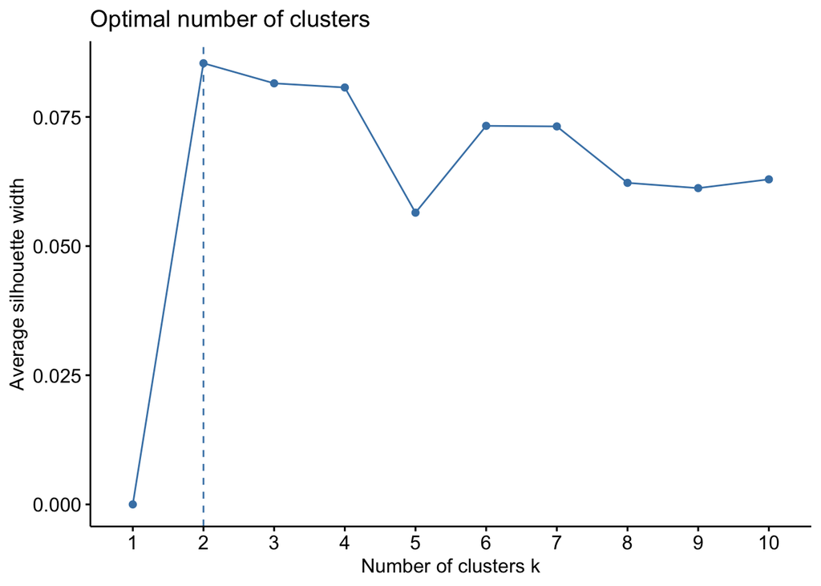

Find the best K value is a trial and error process why fiddling with and tuning what your needs are. K-Means is another introductory and simple algorithm used to cluster data. It is a easy to use algorithm and a really handy algorithm.